# PROGETTO ESAME APPRENDIMENTO STATISTICO

### Emanuele Pinna matr.296455

## Analisi del dataset 'Wine quality'

##### In questo progetto verrà analizzato il dataset 'winequality-red.csv', contenente campioni del vino rosso 'Vinho Verde' del nord del Portogallo.

##### L'obbiettivo è quello di classificare i vari campioni nel dataset secondo la qualità del vino in base ai risultati delle prove chimico-fisiche testate nel campione.

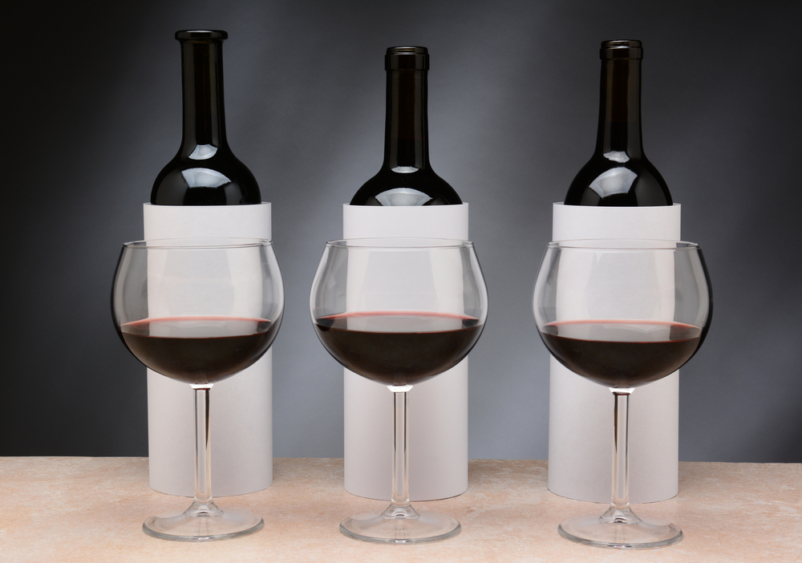

```python
#%matplotlib widget
import pandas as pd
import numpy as np
import matplotlib
import matplotlib.pyplot as plt
from IPython.display import display
import sklearn
import FisherDA
#import kfda
from sklearn.preprocessing import LabelEncoder
from sklearn.decomposition import PCA
from sklearn.discriminant_analysis import LinearDiscriminantAnalysis as LDA
from FisherDA import MultipleFisherDiscriminantAnalysis as FDA
from sklearn.svm import LinearSVC
from sklearn.model_selection import train_test_split
from sklearn import datasets
from sklearn.decomposition import KernelPCA as KPCA
from sklearn.model_selection import GridSearchCV
from sklearn.metrics import f1_score, precision_score, recall_score, confusion_matrix, make_scorer
from sklearn.preprocessing import StandardScaler
from mpl_toolkits.mplot3d import Axes3D
#from kfda import Kfda as KFDA
from sklearn.metrics import mean_squared_error
from sklearn.preprocessing import StandardScaler
import seaborn as sn
```

```python
import pandas as pd
import numpy as np
import matplotlib.pyplot as plt
data = pd.read_csv('winequality-red.csv', sep=';')
```

##### Si vedano di seguito le prime 5 entrate del dataset.

```python
data.head()
```

|  | fixed acidity | volatile acidity | citric acid | residual sugar | chlorides | free sulfur dioxide | total sulfur dioxide | density | pH | sulphates | alcohol | quality |
| --- | --- | --- | --- | --- | --- | --- | --- | --- | --- | --- | --- | --- |
| 0 | 7.4 | 0.70 | 0.00 | 1.9 | 0.076 | 11.0 | 34.0 | 0.9978 | 3.51 | 0.56 | 9.4 | 5 |
| 1 | 7.8 | 0.88 | 0.00 | 2.6 | 0.098 | 25.0 | 67.0 | 0.9968 | 3.20 | 0.68 | 9.8 | 5 |
| 2 | 7.8 | 0.76 | 0.04 | 2.3 | 0.092 | 15.0 | 54.0 | 0.9970 | 3.26 | 0.65 | 9.8 | 5 |
| 3 | 11.2 | 0.28 | 0.56 | 1.9 | 0.075 | 17.0 | 60.0 | 0.9980 | 3.16 | 0.58 | 9.8 | 6 |
| 4 | 7.4 | 0.70 | 0.00 | 1.9 | 0.076 | 11.0 | 34.0 | 0.9978 | 3.51 | 0.56 | 9.4 | 5 |

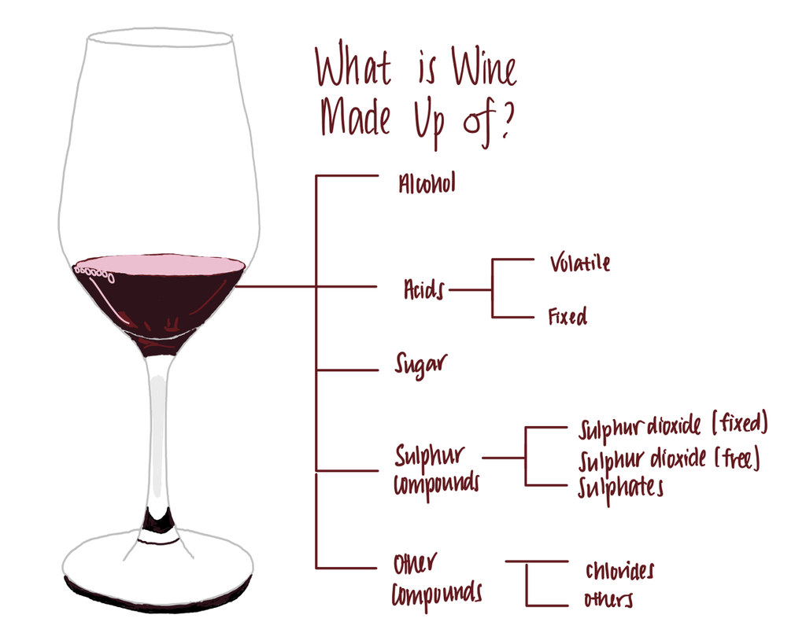

##### Questo dataset è composto da 1599 istanze e 11 features che rappresentano i dati chimico-fisici raccolti dai test.

```python
data.shape
```

```
(1599, 12)
```

##### Si controllino ora quali in quali colonne delle features si hanno valori mancanti.

```python
data.info()
```

```
<class 'pandas.core.frame.DataFrame'>
RangeIndex: 1599 entries, 0 to 1598
Data columns (total 12 columns):
 #   Column                Non-Null Count  Dtype
---  ------                --------------  -----
 0   fixed acidity         1599 non-null   float64
 1   volatile acidity      1599 non-null   float64
 2   citric acid           1599 non-null   float64
 3   residual sugar        1599 non-null   float64
 4   chlorides             1599 non-null   float64
 5   free sulfur dioxide   1599 non-null   float64
 6   total sulfur dioxide  1599 non-null   float64
 7   density               1599 non-null   float64
 8   pH                    1599 non-null   float64
 9   sulphates             1599 non-null   float64
 10  alcohol               1599 non-null   float64
 11  quality               1599 non-null   int64
dtypes: float64(11), int64(1)
memory usage: 150.0 KB
```

##### Come si può notare dalla tabella sottostante non compaiono missing values, in quanto la riga corrispondente al count presenta solo il valore 1599 (numero delle istanze totali del dataset.

```python
# NON CI SONO MISSING VALUES
data.iloc[:,:-1].describe()
```

|  | fixed acidity | volatile acidity | citric acid | residual sugar | chlorides | free sulfur dioxide | total sulfur dioxide | density | pH | sulphates | alcohol |
| --- | --- | --- | --- | --- | --- | --- | --- | --- | --- | --- | --- |
| count | 1599.000000 | 1599.000000 | 1599.000000 | 1599.000000 | 1599.000000 | 1599.000000 | 1599.000000 | 1599.000000 | 1599.000000 | 1599.000000 | 1599.000000 |
| mean | 8.319637 | 0.527821 | 0.270976 | 2.538806 | 0.087467 | 15.874922 | 46.467792 | 0.996747 | 3.311113 | 0.658149 | 10.422983 |
| std | 1.741096 | 0.179060 | 0.194801 | 1.409928 | 0.047065 | 10.460157 | 32.895324 | 0.001887 | 0.154386 | 0.169507 | 1.065668 |
| min | 4.600000 | 0.120000 | 0.000000 | 0.900000 | 0.012000 | 1.000000 | 6.000000 | 0.990070 | 2.740000 | 0.330000 | 8.400000 |
| 25% | 7.100000 | 0.390000 | 0.090000 | 1.900000 | 0.070000 | 7.000000 | 22.000000 | 0.995600 | 3.210000 | 0.550000 | 9.500000 |
| 50% | 7.900000 | 0.520000 | 0.260000 | 2.200000 | 0.079000 | 14.000000 | 38.000000 | 0.996750 | 3.310000 | 0.620000 | 10.200000 |
| 75% | 9.200000 | 0.640000 | 0.420000 | 2.600000 | 0.090000 | 21.000000 | 62.000000 | 0.997835 | 3.400000 | 0.730000 | 11.100000 |
| max | 15.900000 | 1.580000 | 1.000000 | 15.500000 | 0.611000 | 72.000000 | 289.000000 | 1.003690 | 4.010000 | 2.000000 | 14.900000 |

##### vedendo ora la distribuzione delle classi della qualità si nota che le classi sono molto disomogenee e addirittura mancano 5 classi di qualità (0,1,2,9,10)

```python
target_vc = data['quality'].value_counts()
print(target_vc)
```

```
5    681
6    638
7    199
4     53
8     18
3     10
Name: quality, dtype: int64
```

```python
S,T = data.shape
qual_freq = pd.concat([data['quality'].value_counts(), data['quality'].value_counts()/S], axis=1)
qual_freq.columns = ['counts', 'freq.']
qual_freq.index.name = 'quality'

qual_freq
```

| quality | counts | freq. |
| --- | --- | --- |
| 5 | 681 | 0.425891 |
| 6 | 638 | 0.398999 |
| 7 | 199 | 0.124453 |
| 4 | 53 | 0.033146 |
| 8 | 18 | 0.011257 |
| 3 | 10 | 0.006254 |

##### Dalla tabella precedente si nota che il dataset ha una distribuzione molto poco equilibrata, difatti classi come la 5 e la 6 contengono più di 600 campioni mentre le altre vanno diminuendo sia verso 10 che verso l'1. Da questo se ne dedurrà uno scarso potere predittivo del supervised learning in quanto con classi sbilanciate si tende a valorizzare le classi più numerose risultando in una precisione più alta nelle stesse ma più bassa a livello generale.

##### di seguito vi è il plot del numero di istanze per ogni qualità

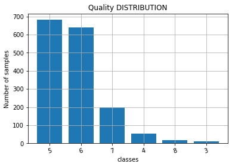

```python
qual_counts = data['quality'].value_counts()

plt.figure()
plt.bar(np.arange(len(qual_counts.values)), qual_counts.values)
plt.xticks(ticks=np.arange(len(qual_counts.values)),
           labels=qual_counts.index.to_list(),
           rotation=15)
plt.title('Quality DISTRIBUTION')
plt.xlabel('classes')
plt.ylabel('Number of samples')
plt.grid()
plt.show()
```

##### e la matrice di correlazione tra le varie features, si può notare come le feature più correlate sono effettivamente le proprietà chimico fisiche dipendenti.

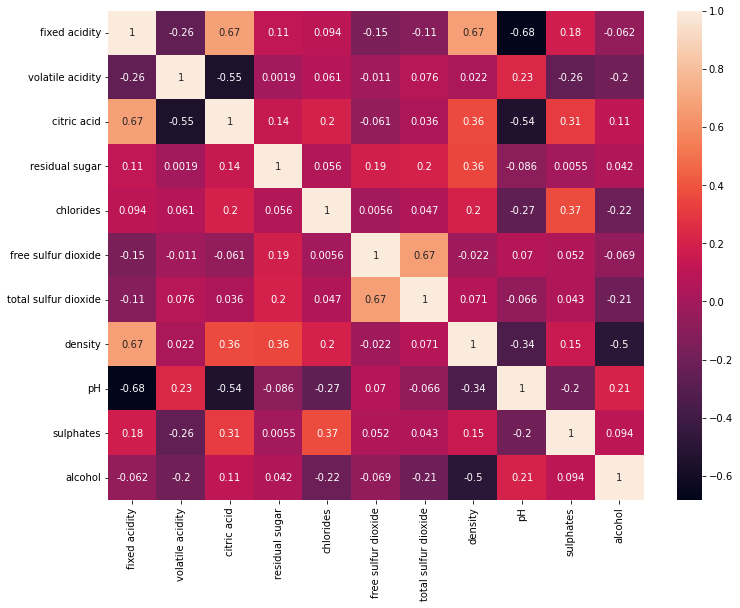

```python
plt.figure(figsize = (12,9))
corrMatrix = data.iloc[:,:-1].corr()
sn.heatmap(corrMatrix, annot=True)
plt.show()
```

##### Ora si crei un training set e un test set dal dataset iniziale con dimensioni del training set e del test set rispettivamente di 2/3 e 1/3 del datset inziale (dimensioni ottimali) in modo tale che la proporzione delle classi rimanga stratificata anche nel training e nel test set.

```python
from sklearn.model_selection import train_test_split
X_train, X_test, y_train, y_test = train_test_split(data.iloc[:,:-1],list(data['quality']),test_size = 0.33, random_state = 7, shuffle = True, stratify = list(data['quality']))
```

##### Si mostrino ora le distribuzioni dei valori delle feature all'interno del training set (non si considera il test set per non avere dei 'leak' di informazioni dallo stesso compromettendo in seguito la generalità del modello).

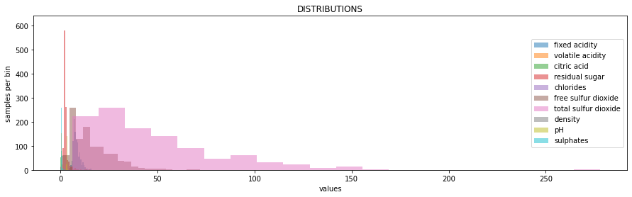

```python
# CONTROLLO RISCALAMENTO DATI
plt.figure(figsize = [15,4])
for col in X_train.columns[0:-1]:
    plt.hist(X_train[col], bins=20, alpha = 0.5)
    plt.xscale('linear')
    plt.title('DISTRIBUTIONS')
    plt.xlabel('values')
    plt.ylabel('samples per bin')
plt.legend(X_train.columns, loc ='right')
plt.show()
```

##### dal precedente grafico si può notare che i valori delle features non sono riscalati in quanto vi è una grande escursione tra i valori delle stesse.

##### Per ovviare questo problema si riscalino tutti i valori delle feature attraverso la funzione di scikit-learn 'StandardScaler'.

```python
from sklearn.preprocessing import StandardScaler as SS
scaler = SS().fit(X_train)
X_train_scaled = scaler.transform(X_train)
X_test_scaled = scaler.transform(X_test)
pp_data = X_train.copy()

for col,x in zip(X_train.columns, X_train_scaled.T):
    pp_data[col] = x

pp_data.head()
```

|  | fixed acidity | volatile acidity | citric acid | residual sugar | chlorides | free sulfur dioxide | total sulfur dioxide | density | pH | sulphates | alcohol |
| --- | --- | --- | --- | --- | --- | --- | --- | --- | --- | --- | --- |
| 1429 | -0.232823 | -1.975326 | 0.658409 | -0.239127 | -0.840129 | 2.143102 | 0.640948 | -0.381398 | 0.125232 | 1.652047 | 0.816780 |
| 1277 | -0.743794 | 0.907043 | -1.397440 | -0.453352 | 0.604637 | -1.224008 | -1.114653 | -0.191438 | 0.257049 | -0.343179 | -0.676323 |
| 711 | 0.334922 | 0.200580 | 0.350032 | 0.332138 | 0.137867 | 0.026633 | 2.026949 | 1.623734 | 0.454774 | -0.282718 | -0.862961 |
| 406 | 0.845893 | -0.505883 | 1.018183 | -0.024903 | -0.528949 | -0.646789 | -0.560253 | 0.726701 | -0.467943 | -0.040872 | 0.350186 |
| 1358 | -0.516696 | 0.624458 | -0.523704 | 2.045934 | 1.804905 | 3.489947 | 1.595748 | 0.336228 | -0.204310 | -0.947793 | -0.862961 |

##### Si vedano ora le distrbuzioni dei valori riscalati delle features.

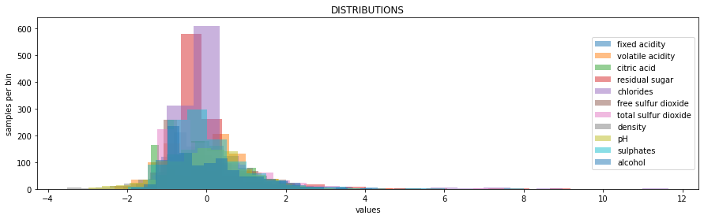

```python
# CONTROLLO RISCALAMENTO DATI
plt.figure(figsize = [15,4])
for col in pp_data.columns:
    plt.hist(pp_data[col], bins=20, alpha = 0.5)
    plt.xscale('linear')
    plt.title('DISTRIBUTIONS')
    plt.xlabel('values')
    plt.ylabel('samples per bin')
plt.legend(pp_data.columns, loc ='right')
plt.show()
```

##### Di seguito invece si plotti, per ogni feature, la distribuzione dei campioni di ogni classe.

##### Si può notare che molte feature portano più varianza tra le distribuzioni delle classi rispetto alle altre, questo si vedrà ancora meglio quando si farà la PCA.

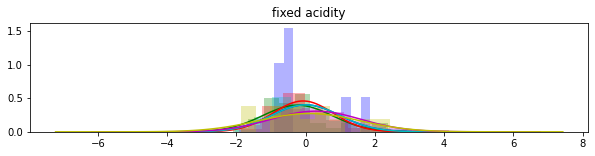

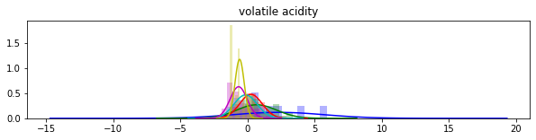

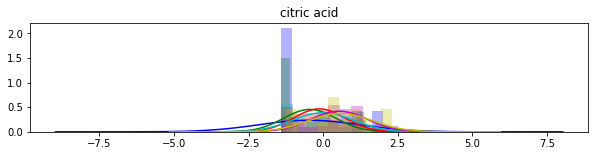

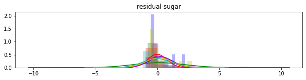

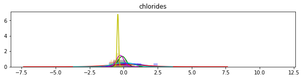

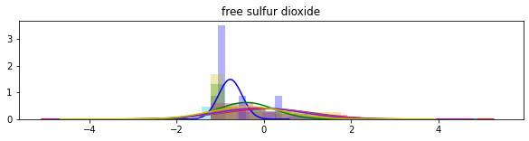

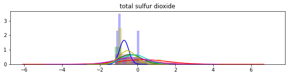

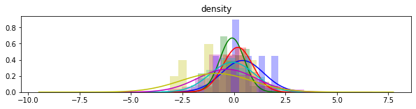

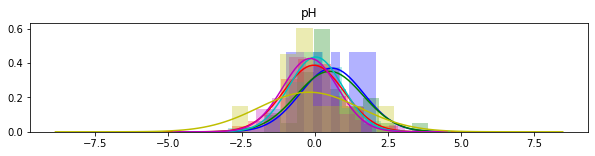

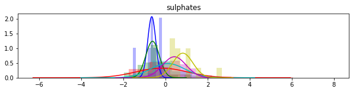

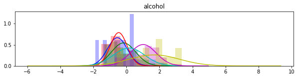

```python
# SET DELLE QUALITA' DEI VINI
qualities = set(y_train)

# CALCOLO DI MEDIA E VARIANZA CAMPIONARIA
means = []
stds = []
idx = range(len(qualities))

datas = []

for t,i in zip(qualities,idx):
    datas.append(pp_data.iloc[np.where(np.array(y_train)==t)])
    means.append([])
    stds.append([])
    for col in pp_data.columns:
        means[i].append(np.mean(datas[i][col]))
        stds[i].append(np.var(datas[i][col]))

means = np.array(means).T
stds = np.array(stds).T


# PLOT DEI RISULTATI OTTENUTI CON IL PREPROCESSING
from scipy.stats import norm

colors = ['b','g','r','c','m','y']
for col,m,v in zip(pp_data.columns, means, stds):
    plt.figure(figsize = [10,2])
    plt.title(col)
    for t,i,color in zip(qualities,idx, colors):
        plt.hist(datas[i][col], density=True, color=color, alpha = 0.3)
        x = np.linspace(m[i]-5*v[i],m[i]+5*v[i],100)
        y = norm(m[i],v[i]).pdf(x)
        plt.plot(x,y, color = color)
```

# SUPERVISED LEARNING (Apprendimento supervisionato)

L'apprendimento supervisionato, noto anche come apprendimento automatico supervisionato, è una sottocategoria di apprendimento automatico e intelligenza artificiale . È definito dall'uso di set di dati etichettati per addestrare algoritmi in grado di classificare i dati o prevedere i risultati in modo accurato. Quando i dati di input vengono inseriti nel modello, esso aggiusta i propri pesi fino a quando il modello non 'fitta' bene i dati, il che avviene come parte del processo di cross-validation.

# Decision Tree Classifier (Albero decisionale)

In generale i metodi basati sugli alberi sia dei buoni regressori che classificatori. L'idea principale è quella di dividere lo spazio delle feature $X$ in regioni più piccole per trovare una funzione di predizione per ogni regione. Poiché l'insieme di regole di divisione utilizzate per segmentare lo spazio predittore può essere riassunto in un albero, questi tipi di approcci sono noti come metodi *Decision-Tree*.

#### Vantaggi e svantaggi

- I metodi basati sugli alberi sono semplici e di facile interpretazione
- Non sono efficienti come i migliori approcci di supervised learning in termini di accuracy
- Combinando un gran numero di alberi si può spesso ottenere un miglioramento nell'accuracy della predizione a scapito della difficoltà interpretativa

#### Processo di Tree-building

1. Si divide lo spazio dei predittori (l'insieme di tutti i possibili valori per $X_1, X_2,\dots, X_p$) in $J$ regioni distinte non sovrapposte
2. Per ogni osservazione che cade nella regione Rj, si fa la stessa predizione, che è semplicemente la media delle variabili response per le osservazioni del training set in $R_j$

In teoria, le regioni potrebbero avere una forma qualsiasi, ma per semplicità di implementazione e di interpretazione si preferisce dividere lo spazio dei predittori in 'scatole alto-dimensionali'. L'obbiettivo è quello di trovare le scatole $R1,\dots,Rj$ tale da minimizzare il *RSS (Residual Sum of Squares)* ovvero la *Loss* calcolata come somma dei quadrati residua $$\sum_{j=1}^J\sum_{i\in R_j}(y_i-\hat{y}_{R_j})^2$$ dove con $\hat{y}_{R_j}$ si indica la media dei response per le osservazioni del training set nella j-esima scatola. L'algoritmo per la formazione dell'albero è il seguente:

1. Si usi la divisione binaria ricorsiva per far crescere un grande albero sul file dati di addestramento, fermandosi solo quando ogni nodo terminale ha meno di un numero minimo di osservazioni.
2. Applicare il cost complexity pruning al grande albero per ottenere una sequenza dei migliori sottoalberi, in funzione di $\alpha$.
3. Usare la K-fold cross-validation per scegliere $\alpha$. Per ogni $k=1,\dots,K$: ripetere step 1 e 2 sulla $\dfrac{K-1}{K}$ frazione del training data, escludendo il kesimo fold

##### Si divida ora il training set a sua volta in training set e validation set, in modo tale da poter testare la performance del modello.

```python
from sklearn.model_selection import train_test_split
from sklearn.metrics import classification_report
from sklearn.metrics import f1_score

X = pp_data
y = y_train
X_train_2, X_valid, y_train_2, y_valid = train_test_split(X,y,test_size=0.33,
                                                   random_state=21,
                                                   stratify=y,shuffle=True)
```

##### Si applichi ora un albero decisionale al training set precedentemente definito.

```python
# TEST DECISION TREE

from sklearn.tree import DecisionTreeClassifier as DTC
from sklearn.tree import plot_tree
dtc = DTC(criterion='gini',max_features='sqrt',
          random_state=7,class_weight=None,max_depth=10)
dtc.fit(X_train_2,y_train_2)
pred_dtc = dtc.predict(X_valid)
print(classification_report(y_valid, pred_dtc))
```

```
              precision    recall  f1-score   support

           3       0.00      0.00      0.00         2
           4       0.29      0.17      0.21        12
           5       0.62      0.71      0.66       151
           6       0.55      0.53      0.54       141
           7       0.37      0.30      0.33        44
           8       0.00      0.00      0.00         4

    accuracy                           0.56       354
   macro avg       0.31      0.28      0.29       354
weighted avg       0.54      0.56      0.55       354
```

##### Come predetto in precedenza, le performance dell'albero decisionale sono scarse in quanto i campioni delle classi sono sbilanciati, risultando in una macro media di circa $0.29$

##### Come accennato in precedenza, il vantaggio degli alberi decisionali è che essi hanno una struttura facilmente visualizzabile.

##### Pertanto si veda qui di seguito la rappresentazione dell'albero risultante.

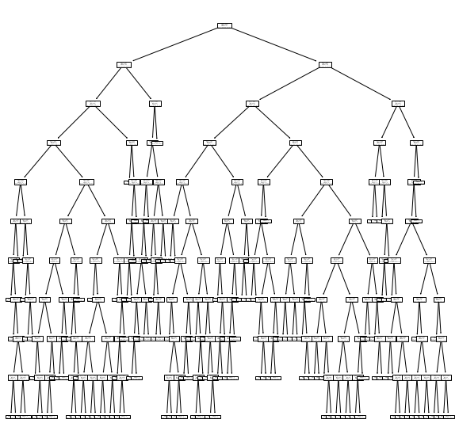

```python
plt.figure(figsize=[10,10])
plot_tree(dtc)
plt.show()
```

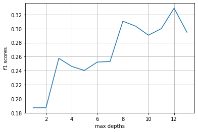

```python
l=[]
for i in range(1,14):
    dtc = DTC(criterion='gini',max_features='sqrt',
          random_state=7,class_weight=None,max_depth=i)
    dtc.fit(X_train_2,y_train_2)
    pred_dtc = dtc.predict(X_valid)
    l.append(f1_score(y_valid, pred_dtc, average='macro'))
plt.figure()
plt.plot(np.arange(13)+1,l)
plt.xlabel('max depths')
plt.ylabel('f1 scores')
plt.grid()
plt.show()
```

# Random Forest Classifier

Il Random Forest Classifier è un metodo di apprendimento supervisionato che costruisce un gran numero di alberi decisionali in degli insiemi campionati con reimmissione (Bootstrap Aggregating o Bagging) per poi passare ad un majority voting per scegliere a quale classe appartiene ogni punto del Test Set.

```python
from sklearn.ensemble import RandomForestClassifier
from sklearn.datasets import make_classification
clf = RandomForestClassifier(max_depth=15, random_state=0, n_estimators=240)
clf.fit(X_train_2, y_train_2)
y_pred = clf.predict(X_valid)
```

```python
from sklearn.metrics import f1_score

f1_score(y_valid, y_pred, average='macro')
```

```
0.31240681800477077
```

##### Si veda come varia l'overfitting con l'aumento della profondità massima

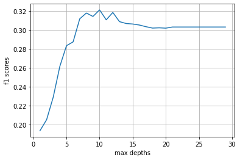

```python
l=[]
for i in range(1,30):
    clf = RandomForestClassifier(max_depth=i, random_state=7, n_estimators=70)
    clf.fit(X_train_2, y_train_2)
    y_pred = clf.predict(X_valid)
    l.append(f1_score(y_valid, y_pred, average='macro'))
plt.figure()
plt.plot(np.arange(29)+1,l)
plt.xlabel('max depths')
plt.ylabel('f1 scores')
plt.grid()
plt.show()
```

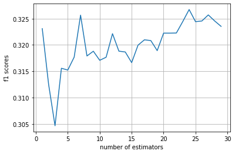

```python
l=[]
for i in range(1,30):
    clf = RandomForestClassifier(max_depth=10, random_state=0, n_estimators=i*10)
    clf.fit(X_train_2, y_train_2)
    y_pred = clf.predict(X_valid)
    l.append(f1_score(y_valid, y_pred, average='macro'))
plt.figure()
plt.plot(np.arange(29)+1,l)
plt.xlabel('number of estimators')
plt.ylabel('f1 scores')
plt.grid()
plt.show()
```

# Support Vector Machine Classifier

Le Support Vector Machine sono dei modelli di apprendimento supervisionato associati ad algoritmi di apprendimento per la regressione e la classificazione. Formalmente, una macchina a vettori di supporto costruisce un iperpiano o un insieme di iperpiani in uno spazio a più dimensioni o a infinite dimensioni. Intuitivamente una buona separazione si può ottenere dall'iperpiano che ha la distanza maggiore dal punto (del training set) più vicino di ognuna delle classi; in generale maggiore è il margine fra questi punti, minore è l'errore di generalizzazione commesso dal classificatore. I vantaggi della SVM sono:

- Buona generalizzazione
- Lavora bene con gli insiemi ben separabili
- Trova globalmente il miglior modello
- L'algoritmo è efficiente
- Si può utilizzare il kernel trick  
  Qualora le classi non siano separabili, si definisce un *soft margin* (ovvero un margine entro il quale possono esserci punti che 'oltrepassano' il piano separatore nonostante appartengano alla stessa classe) che può esssere più o meno rigido a seconda di quanto vengono penalizzati i punti non separati. L'SVM è un problema di ottimizzazione risolvibile grazie ai moltiplicatori di Lagrange applicati al duale.

```python
import numpy as np
from sklearn.svm import SVC
clf2 = SVC(C=31)
clf2.fit(X_train_2, y_train_2)
y_pred = clf2.predict(X_valid)
f1_score(y_valid, y_pred, average='macro')
```

```
0.3071616195729671
```

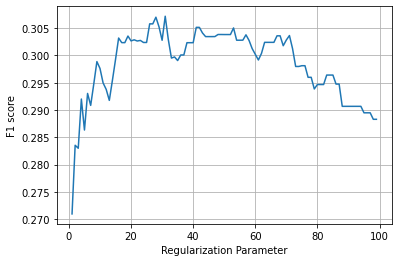

```python
l=[]
for i in range(1,100):
    clf2 = SVC(C=i)
    clf2.fit(X_train_2, y_train_2)
    y_pred = clf2.predict(X_valid)
    l.append(f1_score(y_valid, y_pred, average='macro'))
plt.figure()
plt.plot(np.arange(99)+1,l)
plt.grid()
plt.xlabel('Regularization Parameter')
plt.ylabel('F1 score')
plt.show()
```

Il parametro C dell'SVM indica quanto si desidera evitare di classificare erroneamente ogni esempio di addestramento. Per valori elevati di C, l'ottimizzazione sceglierà un iperpiano con margine più piccolo se quell'iperpiano fa un lavoro migliore nel classificare correttamente tutti i punti di addestramento. Al contrario, un valore molto piccolo di C farà sì che l'ottimizzatore cerchi un iperpiano di separazione con margini maggiori, anche se quell'iperpiano classifica erroneamente più punti.

# UNSUPERVISED LEARNING

L'Unsupervised Learning (o Apprendimento non supervisionato) si riferisce all'uso di algoritmi di intelligenza artificiale per identificare modelli in set di dati contenenti punti dati che non sono né classificati nè etichettati. In altre parole, l'apprendimento non supervisionato consente al sistema di identificare autonomamente i modelli all'interno del set di dati. Nell'apprendimento non supervisionato, un sistema di intelligenza artificiale raggruppa le informazioni non ordinate in base a somiglianze e differenze (tramite le features) anche se non vengono fornite classi.

# Principal Component Analysis

#### Principal Component Analysis

La **Principal Component Analysis (PCA)** è uno strumento molto utilizzato per la riduzione lineare della dimensionalità e per l'estrazione delle feature (caratteristiche). Lo scopo della PCA è quello di trovare un sottospazio lineare di dimensionalità fissata inferiore allo spazio delle feature originale, dove le nuove feature abbiano la massima varianza possibile.

Si consideri un dataset $\{x_i\}$ dove $i=1,2,...,N$, ed ogni $x_i$ un vettore D-dimensionale. Ora si vuole proiettare i dati su un sottospazio M-dimensionale, con $M<D$. Assumendo la proiezione denotata come $y=Ax$, dove $A=[u_1^T,...,u_M^T]$ e $u_k^Tu_k=1$ per $k=1,2,...,M$, si cerca di massimizzare la varianza di $\{y_i\}$, che è la traccia della matrice di covarianza di $\{y_i\}$. Così, bisogna trovare $$A^*=\arg\max_A tr(S_y)$$ dove $$S_y=\frac{1}{N}\sum_{i=1}^N(y_i-\bar{y})(y_i-\bar{y})^T$$ e $$\bar{y}=\frac{1}{N}\sum_{i=1}^Nx_i.$$ Sia $S_x$ la matrice di covarianza di $\{x_i\}$. Dato che $tr(S_y)=tr(AS_xA^T)$, usando il Moltiplicatore Lagrangiano e prendendo le derivate, si ottiene $$S_xu_k=\lambda_ku_k$$ che significa che $u_k$ è un autovettore di $S_x$. Ora $x_i$ può essere rappresentata come $$x_i=\sum_{k=1}^D(x_i^Tu_k)u_k.$$ $x_i$ può anche essere approssimato da $$\tilde{x}_i=\sum_{i=1}^M(x_i^Tu_k)u_k,$$ dove $u_k$ è l'autovettore di $S_x$ corrispondente al k-esimo autovalore più grande.

##### Si vedano di sequito qualsi sono le componenti principali che spiegano più varianza.

```python
X = pp_data.values
y = y_train
```

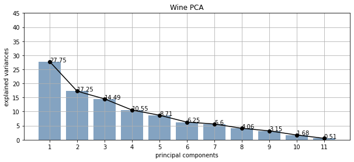

```python
# VOGLIO VEDERE QUALI SONO LE COMPONENTI PRINCIPALI CHE SPIEGANO PIU VARIANZA
from sklearn.decomposition import PCA

color = (0.2, 0.4, 0.6, 0.6)

pca = PCA().fit(X,y)

# scelta componenti principali
plt.figure(figsize = [10,4])
plt.plot(np.arange(1,12),pca.explained_variance_ratio_*100, 'ko')
plt.plot(np.arange(1,12),pca.explained_variance_ratio_*100, 'k')
for i,var in zip(range(1,12), pca.explained_variance_ratio_*100):
    plt.annotate(round(var,2),[i,var])
plt.bar(np.arange(1,12),height = pca.explained_variance_ratio_*100, color = color)
plt.grid()
plt.xlabel('principal components')
plt.xticks(np.arange(1,12))
plt.yticks(np.arange(0,50,5))
plt.ylabel('explained variances')

#plt.semilogy()
plt.title('Wine PCA')
plt.show()
```

##### Si veda ora come aumenta la varianza spiegata con l'aggiunta delle componenti principali, si noti che il grafico prende la tipica forna a 'gomito' che ottimizza la scelta del numero di componenti principali da considerare.

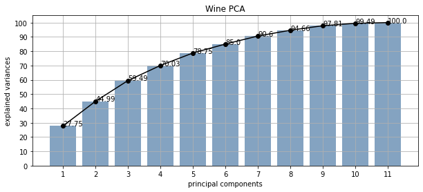

```python
# controllo sulla distribuzione cumulativa
# scelta componenti principali

plt.figure(figsize = [10,4])
plt.plot(np.arange(1,12),pca.explained_variance_ratio_.cumsum()*100, 'ko')
plt.plot(np.arange(1,12),pca.explained_variance_ratio_.cumsum()*100, 'k')
for i,var in zip(range(1,12), pca.explained_variance_ratio_.cumsum()*100):
    plt.annotate(round(var,2),[i,var])
plt.bar(np.arange(1,12),height = pca.explained_variance_ratio_.cumsum()*100, color = color)
plt.grid()
plt.xlabel('principal components')
plt.xticks(np.arange(1,12))
plt.yticks(np.arange(0,110,10))
plt.ylabel('explained variances')
plt.title('Wine PCA')
plt.show()
```

```python
X = pp_data.values
y = y_train
```

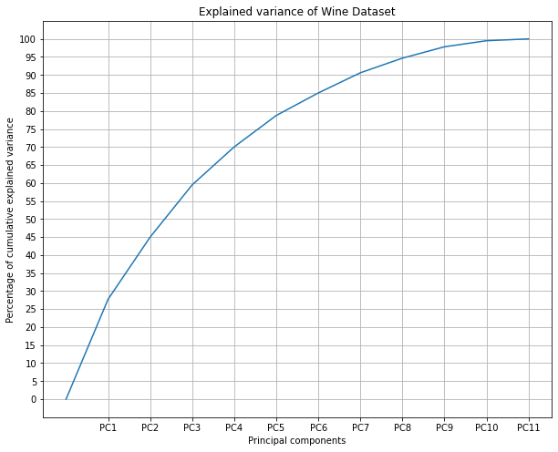

```python
pca_wine = PCA()
scaler = StandardScaler()
scaler.fit(X)
Xscaled = scaler.transform(X)
pca_wine.fit(Xscaled)


plt.figure(figsize=(10,8))
plt.plot(100*np.insert(np.cumsum(pca_wine.explained_variance_ratio_), 0, 0))
plt.title('Explained variance of Wine Dataset')
plt.xticks(ticks=np.arange(1, pca_wine.n_features_ + 1),
           labels=[f'PC{i}' for i in range(1, pca_wine.n_features_ + 1)])
plt.yticks(ticks=np.arange(0, 101, 5))
plt.xlabel('Principal components')
plt.ylabel('Percentage of cumulative explained variance')
plt.grid()
plt.show()
```

##### Qui di seguito è rappresentato invece il grafico bidimensionale e tridimensionale delle classi rispetto alle prime 2 e 3 componenti principali.

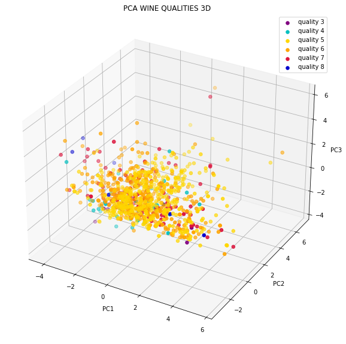

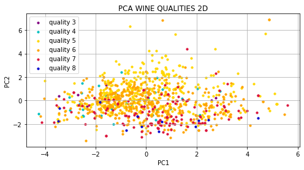

```python
#3D plot
data_pca = pca.transform(pp_data)

fig = plt.figure()
ax = fig.add_subplot(projection='3d')
plt.title('PCA WINE QUALITIES 3D')
for t,c,w in zip(qualities,['purple','c','gold','orange','crimson','mediumblue',
                           'dimgrey'],['quality 3','quality 4','quality 5','quality 6',
                                       'quality 7','quality 8']):
    ax.set_xlabel('PC1')
    ax.set_ylabel('PC2')
    ax.set_zlabel('PC3')
    ax.scatter(data_pca[np.where(np.array(y_train)==t)][:,0],
               data_pca[np.where(np.array(y_train)==t)][:,1],
               data_pca[np.where(np.array(y_train)==t)][:,2],
               color = c, s = 30, label = w)
ax.legend()
fig.set_size_inches(10,10)
plt.show()

#2D plot
plt.figure(figsize = [8,4])
for t,c,w in zip(qualities,['purple','c','gold','orange','crimson','mediumblue',
                           'dimgrey'],['quality 3','quality 4','quality 5','quality 6',
                                       'quality 7','quality 8']):
    plt.scatter(data_pca[np.where(np.array(y_train)==t)][:,0],
                data_pca[np.where(np.array(y_train)==t)][:,1],
                s = 10, color = c, label = w)
    plt.title('PCA WINE QUALITIES 2D')
    plt.xlabel('PC1')
    plt.ylabel('PC2')
plt.legend()
plt.grid()
plt.show()
```

```
Numero PC: 9
% Varianza Tot. Spiegata: 0.9780910663818869
```

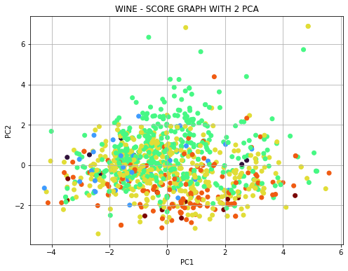

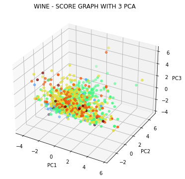

```python
pca_wine_m = PCA(0.95)
pca_wine_m.fit(Xscaled)
X_wine_m = pca_wine_m.transform(Xscaled)
num_tosee = 1000
print('Numero PC: {}'.format(pca_wine_m.n_components_))
print('% Varianza Tot. Spiegata: {}'.format(pca_wine_m.explained_variance_ratio_.sum()))


plt.figure(figsize=(8, 6))
plt.scatter(X_wine_m[:, 0], X_wine_m[:, 1], c=y, cmap='turbo')
plt.title('WINE - SCORE GRAPH WITH 2 PCA')
plt.xlabel('PC1')
plt.ylabel('PC2')
plt.grid()
plt.show()

fig_beanscore = plt.figure(figsize=(8, 6))
ax = fig_beanscore.add_subplot(111, projection='3d')
ax.scatter(X_wine_m[:, 0], X_wine_m[:, 1], X_wine_m[:, 2], c=y, cmap='turbo')
plt.title('WINE - SCORE GRAPH WITH 3 PCA')
ax.set_xlabel('PC1')
ax.set_ylabel('PC2')
ax.set_zlabel('PC3')
plt.grid()
plt.show()
```

Si riapplichi la SVM ai dati trasformati dalla PCA

```python
X_test_scaled = scaler.transform(X_test)
X_test_m = pca_wine_m.transform(X_test_scaled)
clf2 = SVC(C=30)
clf2.fit(X_wine_m, y_train)
y_pred = clf2.predict(X_test_m)
f1_score(y_test, y_pred, average='macro')
```

```
0.09960159362549799
```